# UCDP GED Clusteranalyse

Teichgräber  
2026-03-20

## Clusteranalyse von Konfliktereignissen in der Sahelzone

**Libraries laden**

**Aufklappen**

```r
library(lubridate)
library(dplyr)
library(tidyr)
library(ggplot2)
library(distill)
library(sf)
library(dbscan)
library(rnaturalearth)
library(rnaturalearthdata)
```

**Info zum Herunterladen des Datensatzes**

Der Datensatz wurde über das UCDP Dataset Download Center heruntergeladen (Link im nächsten Code Chunk hinterlegt).

R Studio konnte den Datensatz erst einlesen, nachdem dieser als xlsx-Datei heruntergeladen und in eine csv-Datei umgewandelt wurde. Hierbei wurde das Semikolon als Trennzeichen festgelegt.

Bei der Analyse wurde ein verkürzter Datensatz verwendet, da Spalten entfernt wurden, um die Größ der Datei zu verringern. Die Analyse funtkioniert jedoch auch mit der unveränderten Datei problemlos.

**Datensatz laden**

**Aufklappen**

```r
# Laden der Daten
# Das Trennzeichen ist wegen der Deutschen Version von xlsx bzw. csv ein Semikolon
# Quelle des Datensatzes: https://ucdp.uu.se/downloads/
# Der Datensatz ist hinterlegt und im Ordner data abgespeichert

GED = read.csv("data/GEDEvent_v25_1_small.csv", sep = ";")

# GED = read.csv("data/GEDEvent_v25_1_big.csv", sep = ";")
```

**Erste Übersicht der Daten**

**Aufklappen**

```r
# Strukturprüfung des gesamten Datensatzes
# Anzahl der Beobachtungen, Anzahl der Variablen und aktuelle Datentypen prüfen

str(GED)
```

```
'data.frame':   385918 obs. of  35 variables:
 $ id               : int  244657 412700 413023 412909 132140 130364 130359 133883 133874 133878 ...
 $ year             : int  2017 2021 2021 2021 1989 1989 1989 1989 1989 1989 ...
 $ active_year      : chr  "true" "true" "true" "true" ...
 $ type_of_violence : int  1 1 1 1 1 1 1 1 1 1 ...
 $ conflict_new_id  : int  259 259 259 259 333 333 333 333 333 333 ...
 $ conflict_name    : chr  "Iraq: Government" "Iraq: Government" "Iraq: Government" "Iraq: Government" ...
 $ dyad_new_id      : int  524 524 524 524 724 724 724 724 724 724 ...
 $ dyad_name        : chr  "Government of Iraq - IS" "Government of Iraq - IS" "Government of Iraq - IS" "Government of Iraq - IS" ...
 $ side_a_new_id    : int  116 116 116 116 130 130 130 130 130 130 ...
 $ side_a           : chr  "Government of Iraq" "Government of Iraq" "Government of Iraq" "Government of Iraq" ...
 $ side_b_new_id    : int  234 234 234 234 292 292 292 292 292 292 ...
 $ side_b           : chr  "IS" "IS" "IS" "IS" ...
 $ number_of_sources: int  3 15 5 8 -1 -1 -1 -1 -1 -1 ...
 $ where_prec       : int  1 1 1 1 4 4 1 1 2 4 ...
```

[output cut: 21 more lines]

# Aufbereitung der Daten bzw. Variablen

**Aufklappen**

```r
GED <- GED |>
  mutate(

    # 1)

    active_year = tolower(active_year) == "true",

    # 2)

    latitude  = as.numeric(gsub(",", ".", latitude)),
    longitude = as.numeric(gsub(",", ".", longitude)),

    # 3)

    # Verwenden beim verkürzten Datensatz

    #date_start = dmy(date_start),
    #date_end = dmy(date_end),

    # Verwenden beim unveränderten Datensatz

    date_start = ymd(date_start),
    date_end = ymd(date_end),

  ) |>

    # 4)

  drop_na(latitude, longitude)
```

**Erklärung**

**Aufklappen**

```r
# Überschreibung des Datensatzes mit den veränderten Daten und entfernen von unvollständigen Zeilen

# 1) Aktives Jahr: Der Wert der Variablen "true"/"false" wird von einer Zeichenkette (character) nun als logischer Wert (TRUE/FALSE) definiert

# 2) Koordinaten: Das Dezimalzeichen wird von Komma zu Punkt geändert und als numeric definiert, da standardmäßig der Punkt das Dezimaltrennzeichen ist

# 3) Datum: Die Variablen date_start und date_end werden von einer  Zeichenkette (character) in ein Datumsformat gebracht

# 4) Zeilen mit fehlenden geographischen Daten werden entfernt.
#    Diese Beobachtungen können nicht als räumliche Punkte dargestellt werden und deshalb nicht in die Clusteranalyse einbezogen werden.
```

# Prüfung der geographischen Daten (fehlende Werte)

**Sind fehlende Werte bei den geographischen Daten vorhanden?**

**Aufklappen**

```r
sum(is.na(GED$latitude))
```

```
[1] 0
```

**Aufklappen**

```r
sum(is.na(GED$longitude))
```

```
[1] 0
```

**Befinden sich geographische Werte außerhalb der logischen Bereiche?**

**Aufklappen**

```r
sum(GED$latitude < -90 | GED$latitude > 90, na.rm = TRUE)
```

```
[1] 0
```

**Aufklappen**

```r
sum(GED$longitude < -180 | GED$longitude > 180, na.rm = TRUE)
```

```
[1] 0
```

# Beschreibung der wichtigsten Variablen

**Auflistung aller notwendigen Variablen des Datensatzes**

**Aufklappen**

```r
# Abfrage der Spaltennamen bzw. Namen der Variablen

colnames(GED)
```

```
 [1] "id"                "year"              "active_year"
 [4] "type_of_violence"  "conflict_new_id"   "conflict_name"
 [7] "dyad_new_id"       "dyad_name"         "side_a_new_id"
[10] "side_a"            "side_b_new_id"     "side_b"
[13] "number_of_sources" "where_prec"        "where_coordinates"
[16] "where_description" "adm_1"             "adm_2"
[19] "latitude"          "longitude"         "geom_wkt"
[22] "country"           "country_id"        "region"
[25] "event_clarity"     "date_prec"         "date_start"
[28] "date_end"          "deaths_a"          "deaths_b"
[31] "deaths_civilians"  "deaths_unknown"    "best"
[34] "high"              "low"
```

**Inhalt der genutzten Variablen**

Informationen stammen aus dem Codebook des GED 25.1!

**“id”** Eine eindeutige, dauerhafte numerische ID eines einzelnen Ereignisses. Dieselbe id bezeichnet über mehrere GED-Versionen hinweg dasselbe reale Ereignis.

**“year”** Das Jahr, in dem das Ereignis stattgefunden hat.

**“type_of_violence”** Der Typ der organisierten Gewalt nach dem UCDP: 1 = staatlicher Konflikt, 2 = nichtstaatlicher Konflikt, 3 = einseitige Gewalt gegen Zivilisten.

**“conflict_new_id”** Eine eindeutige Konflikt-ID für jeden einzelnen Konflikt im Datensatz. Ist geeignet zum Filtern von Konflikten.

**“conflict_name”** Der Name des UCDP-Konflikts, zu dem das Ereignis gehört.

**“event_clarity”** Eine 1 (hoch) steht für Ereignisse, bei denen der Berichterstatter das Ereignis vollständig identifizieren kann. Das bedeutet, dass das einzelne Geschehen von der Originalquelle ausreichend detailliert beschrieben wird, um einzelne Vorfälle zu identifizieren.

**“latitude”** Breitengrad des Ereignisortes in Dezimalgrad.

**“longitude”** Längengrad des Ereignisortes in Dezimalgrad.

**“where_prec”** Die Genauigkeit, mit der die dem Ereignis zugewiesenen Koordinaten und der Standort den tatsächlichen Standort des Ereignisses widerspiegeln. Eine 1 bedeutet, dass der genaue Standort des Ereignisses bekannt ist.

**“country”**  
Das Land, in dem das Ereignis tatsächlich stattgefunden hat.

**“region”** Die Weltregion bzw. der Kontinent des Ereignisortes.

**“date_start”** Das früheste mögliche Datum, an dem das Ereignis stattgefunden haben kann.

**“date_end”** Das späteste mögliche Datum, an dem das Ereignis stattgefunden haben kann.

**“deaths_civilians”** Die beste Schätzung der getöteten Zivilpersonen im Ereignis.

**“best”**  
Die beste bzw. wahrscheinlichste Schätzung der gesamten Todesopfer des Ereignisses. Sie ist die Summe aus deaths_a, deaths_b, deaths_civilians und deaths_unknown.

**“high”** Die höchste verlässliche Schätzung der gesamten Todesopfer des Ereignisses.

# Deskriptive Analyse des gesamten Datensatzes

**Code mit Kommentaren versehen**

**Danach folgen die Ausgaben**

**Aufklappen**

```r
# Deskriptive Analyse des gesamten GED-Datensatzes

# cat wird für eine einfache Ausgabe von Text verwendet


# Lesbare Bezeichnungen (labels) für die Gewalttypen nach UCDP

violence_labels <- c(
  "1" = "Staatlicher Konflikt",
  "2" = "Nichtstaatlicher Konflikt",
  "3" = "Einseitige Gewalt gegen Zivilisten"
)

# Hilfsfunktion zur Formatierung großer Zahlen (deutsches Zahlenformat)

fmt <- function(x) {
  format(x, big.mark = ".", decimal.mark = ",")
}

# 1) Gesamtanzahl an Konflikten

n_conflicts_total <- n_distinct(GED$conflict_new_id)

# 2) Konflikte nach Gewalttyp

conflicts_by_type <- GED |>
  distinct(conflict_new_id, type_of_violence) |>
  count(type_of_violence, name = "n_conflicts") |>
  mutate(
    type_of_violence = violence_labels[as.character(type_of_violence)]
  )

# 3) Gesamtanzahl an Events

n_events_total <- nrow(GED)

# 4) Gesamtanzahl der Todesopfer (best)

total_deaths_best <- sum(GED$best, na.rm = TRUE)

# 5) Gesamtanzahl ziviler Todesopfer

total_deaths_civilians <- sum(GED$deaths_civilians, na.rm = TRUE)

# 6) Zeitraum des Datensatzes

year_start <- min(GED$year, na.rm = TRUE)
year_end <- max(GED$year, na.rm = TRUE)
n_years <- year_end - year_start + 1

# Ausgabe der Ergebnisse des gesamten Datensatzes

cat("Deskriptive Analyse des gesamten Datensatzes\n")
```

```
Deskriptive Analyse des gesamten Datensatzes
```

**Aufklappen**

```r
cat("Gesamtanzahl an Konflikten:", fmt(n_conflicts_total), "\n")
```

```
Gesamtanzahl an Konflikten: 1.531
```

**Aufklappen**

```r
cat("Gesamtanzahl an Konfliktereignissen (Events):", fmt(n_events_total), "\n")
```

```
Gesamtanzahl an Konfliktereignissen (Events): 385.918
```

**Aufklappen**

```r
cat("Gesamte Todeszahl (best):", fmt(total_deaths_best), "\n")
```

```
Gesamte Todeszahl (best): 3.957.143
```

**Aufklappen**

```r
cat("Gesamte Zahl ziviler Todesopfer:", fmt(total_deaths_civilians), "\n\n")
```

```
Gesamte Zahl ziviler Todesopfer: 1.474.095
```

**Aufklappen**

```r
cat("Abgedeckter Zeitraum:", year_start, "-", year_end, "(", n_years, "Jahre )\n")
```

```
Abgedeckter Zeitraum: 1989 - 2024 ( 36 Jahre )
```

**Aufklappen**

```r
cat("Konflikte nach Gewalttyp:\n")
```

```
Konflikte nach Gewalttyp:
```

**Aufklappen**

```r
print(conflicts_by_type)
```

```
                    type_of_violence n_conflicts
1               Staatlicher Konflikt         201
2          Nichtstaatlicher Konflikt         967
3 Einseitige Gewalt gegen Zivilisten         363
```

# Deskriptive Analyse der Daten bezüglich Afrika und der Sahel-Zone

**Code mit Kommentaren** **Danach folgen die Ausgaben**

**Aufklappen**

```r
# Deskriptive Analyse für Afrika und Sahel (ab dem Jahr 2000)

# Afrika


# Eingrenzung der Daten

GED_africa <- GED |>
  filter(region == "Africa") |>
  filter(year >= 2000)

# Lesbare Bezeichnungen für die Gewalttypen nach UCDP

violence_labels <- c(
  "1" = "Staatlicher Konflikt",
  "2" = "Nichtstaatlicher Konflikt",
  "3" = "Einseitige Gewalt gegen Zivilisten"
)

# Hilfsfunktion zur Formatierung großer Zahlen (deutsches Zahlenformat)

fmt <- function(x) {
  format(x, big.mark = ".", decimal.mark = ",")
}

# 1) Gesamtanzahl an Konflikten

n_conflicts_africa <- n_distinct(GED_africa$conflict_new_id)

# 2) Konflikte nach Gewalttyp

conflicts_by_type_africa <- GED_africa |>
  distinct(conflict_new_id, type_of_violence) |>
  count(type_of_violence, name = "n_conflicts") |>
  mutate(
    type_of_violence = violence_labels[as.character(type_of_violence)]
  )

# 3) Gesamtanzahl an Events

n_events_africa <- nrow(GED_africa)

# 4) Gesamtanzahl der Todesopfer

total_deaths_best_africa <- sum(GED_africa$best, na.rm = TRUE)
total_deaths_civilians_africa <- sum(GED_africa$deaths_civilians, na.rm = TRUE)


# --------------------------------------------------------------------------------


# Sahel-Zone


# Eingrenzung der Daten

sahel_countries <- c("Senegal",
                     "Mauritania",
                     "Mali",
                     "Burkina Faso",
                     "Niger",
                     "Chad",
                     "Sudan")

GED_sahel_desc <- GED_africa |>
  filter(country %in% sahel_countries)

# 1) Gesamtanzahl an Konflikten

n_conflicts_sahel <- n_distinct(GED_sahel_desc$conflict_new_id)

# 2) Konflikte nach Gewalttyp

conflicts_by_type_sahel <- GED_sahel_desc |>
  distinct(conflict_new_id, type_of_violence) |>
  count(type_of_violence, name = "n_conflicts") |>
  mutate(
    type_of_violence = violence_labels[as.character(type_of_violence)]
  )

# 3) Gesamtanzahl an Events

n_events_sahel <- nrow(GED_sahel_desc)

# 4) Gesamtanzahl der Todesopfer

total_deaths_best_sahel <- sum(GED_sahel_desc$best, na.rm = TRUE)
total_deaths_civilians_sahel <- sum(GED_sahel_desc$deaths_civilians, na.rm = TRUE)


# Ausgabe der Ergebnisse zu Afrika

cat("Deskriptive Analyse: Afrika (ab 2000)\n")
```

```
Deskriptive Analyse: Afrika (ab 2000)
```

**Aufklappen**

```r
cat("Gesamtanzahl an Konflikten:", fmt(n_conflicts_africa), "\n")
```

```
Gesamtanzahl an Konflikten: 754
```

**Aufklappen**

```r
cat("Gesamtanzahl an Konfliktereignissen (Events):", fmt(n_events_africa), "\n")
```

```
Gesamtanzahl an Konfliktereignissen (Events): 52.148
```

**Aufklappen**

```r
cat("Gesamte Todeszahl (best):", fmt(total_deaths_best_africa), "\n")
```

```
Gesamte Todeszahl (best): 792.996
```

**Aufklappen**

```r
cat("Gesamte Zahl ziviler Todesopfer:", fmt(total_deaths_civilians_africa), "\n\n")
```

```
Gesamte Zahl ziviler Todesopfer: 156.382
```

**Aufklappen**

```r
cat("Konflikte nach Gewalttyp in Afrika:\n")
```

```
Konflikte nach Gewalttyp in Afrika:
```

**Aufklappen**

```r
print(conflicts_by_type_africa)
```

```
                    type_of_violence n_conflicts
1               Staatlicher Konflikt          70
2          Nichtstaatlicher Konflikt         515
3 Einseitige Gewalt gegen Zivilisten         169
```

**Aufklappen**

```r
# Ausgabe der Ergebnisse zur Sahel-Zone

cat("Deskriptive Analyse: Sahel-Zone (ab 2000)\n")
```

```
Deskriptive Analyse: Sahel-Zone (ab 2000)
```

**Aufklappen**

```r
cat("Gesamtanzahl an Konflikten:", fmt(n_conflicts_sahel), "\n")
```

```
Gesamtanzahl an Konflikten: 164
```

**Aufklappen**

```r
cat("Gesamtanzahl an Konfliktereignissen (Events):", fmt(n_events_sahel), "\n")
```

```
Gesamtanzahl an Konfliktereignissen (Events): 9.282
```

**Aufklappen**

```r
cat("Gesamte Todeszahl (best):", fmt(total_deaths_best_sahel), "\n")
```

```
Gesamte Todeszahl (best): 115.328
```

**Aufklappen**

```r
cat("Gesamte Zahl ziviler Todesopfer:", fmt(total_deaths_civilians_sahel), "\n\n")
```

```
Gesamte Zahl ziviler Todesopfer: 38.687
```

**Aufklappen**

```r
cat("Konflikte nach Gewalttyp in der Sahel-Zone:\n")
```

```
Konflikte nach Gewalttyp in der Sahel-Zone:
```

**Aufklappen**

```r
print(conflicts_by_type_sahel)
```

```
                    type_of_violence n_conflicts
1               Staatlicher Konflikt          21
2          Nichtstaatlicher Konflikt         111
3 Einseitige Gewalt gegen Zivilisten          32
```

# Aufbau und Durchführung der Datenanalyse (exploratives Clustering) mit Beschreibung

Für die Durchführung der Clusteranalyse sind verschiedene Schritte notwendig.

# 1. Eingrenzung der Daten zur späteren Clusteranalyse

**Aufklappen**

```r
sahel_countries <- c("Senegal",
                     "Mauritania",
                     "Mali",
                     "Burkina Faso",
                     "Niger",
                     "Chad",
                     "Sudan")

GED_sahel <- GED |>
  filter(country %in% sahel_countries) |>
  filter(year >= 2000) |>
  filter(where_prec %in% c(1, 2)) |>
  filter(event_clarity == 1)
```

**Erklärung**

**Aufklappen**

```r
# Die Länder der Region der späteren Clusteranalyse werden festgehalten (dafür wird ein Vektor genutzt)

# Es wird ein neuer Datensatz auf Grundlage der benötigten Filter definiert und geladen
# --> Der Prozess der Speicherung eines neuen Datensatzes wird bei mehreren Schritten angewendet

# Gefilterte Teilmenge: Länder der Sahelzone, Zeitrahmen ab 2000, hohe Genauigkeit der geographischen Daten, hohe Klarheit des Ereignisses

# Der Begriff %in% prüft, ob der Wert in einem Vektor enthalten ist

# Ziel des Schrittes ist die Definition der Grundgesamtheit
```

**Aufklappen**

```r
unique(GED_sahel$country)
```

```
[1] "Burkina Faso" "Chad"         "Mali"         "Mauritania"
[5] "Niger"        "Senegal"      "Sudan"
```

**Aufklappen**

```r
glimpse(GED_sahel)
```

```
Rows: 6,270
Columns: 35
$ id                <int> 244175, 255728, 268816, 271818, 274472, 27…
$ year              <int> 2017, 2018, 2018, 2018, 2018, 2019, 2019, …
$ active_year       <lgl> TRUE, TRUE, TRUE, TRUE, TRUE, TRUE, TRUE, …
$ type_of_violence  <int> 3, 3, 3, 3, 3, 3, 3, 3, 3, 3, 3, 3, 3, 3, …
$ conflict_new_id   <int> 506, 506, 506, 506, 506, 506, 506, 506, 50…
$ conflict_name     <chr> "IS - Civilians", "IS - Civilians", "IS - …
$ dyad_new_id       <int> 973, 973, 973, 973, 973, 973, 973, 973, 97…
$ dyad_name         <chr> "IS - Civilians", "IS - Civilians", "IS - …
$ side_a_new_id     <int> 234, 234, 234, 234, 234, 234, 234, 234, 23…
$ side_a            <chr> "IS", "IS", "IS", "IS", "IS", "IS", "IS", …
$ side_b_new_id     <int> 1, 1, 1, 1, 1, 1, 1, 1, 1, 1, 1, 1, 1, 1, …
$ side_b            <chr> "Civilians", "Civilians", "Civilians", "Ci…
$ number_of_sources <int> 1, 2, 1, 1, 2, 2, 1, 1, 4, 1, 1, 2, 3, 1, …
```

[output cut: 22 more lines]

**Erklärung der Prüfung**

**Aufklappen**

```r
# Überprüfung, ob die Filter korrekt sind und wie viele Beobachtungen übrig bleiben

# Es dürfen nun nur noch die sieben ausgewählten Länder angezeigt werden
# Geographische Daten nun im dbl (numeric) Format
# Zeitangaben nun im date Format
```

# 2. Erstellung geometrischer Punkte

**Aufklappen**

```r
GED_sahel_sf <- GED_sahel |>
  st_as_sf(
    coords = c("longitude", "latitude"),  # x = longitude, y = latitude
    crs = 4326,                           # WGS84 / EPSG:4326 (Grad)
    remove = FALSE                        # Datensatz behält latitude/longitude als Spalten
  )
```

**Erklärung**

**Aufklappen**

```r
# Neuer Datensatz wird erstellt mit allen vorherigen Variablen und mit einer neuen Spalte geometry (geometrischer Punkt)


# Zweck: Umwandlung des Datensatzes in ein räumliches sf-Objekt

# sf ("simple features") ist ein Datenformat für Geodaten in R, bei dem jeder Datensatz eine Geometrie (einen Punkt) besitzt

# CRS = Coordinate Reference System
# Es beschreibt, wie Koordinaten auf der Erdoberfläche interpretiert werden

# EPSG:4326 entspricht dem geographischen Koordinatensystem WGS84, das auch von GPS-Systemen verwendet wird
# Die Koordinaten liegen hier in Grad vor (Breite/Länge)
```

**Aufklappen**

```r
st_crs(GED_sahel_sf)
```

```
Coordinate Reference System:
  User input: EPSG:4326
  wkt:
GEOGCRS["WGS 84",
    ENSEMBLE["World Geodetic System 1984 ensemble",
        MEMBER["World Geodetic System 1984 (Transit)"],
        MEMBER["World Geodetic System 1984 (G730)"],
        MEMBER["World Geodetic System 1984 (G873)"],
        MEMBER["World Geodetic System 1984 (G1150)"],
        MEMBER["World Geodetic System 1984 (G1674)"],
        MEMBER["World Geodetic System 1984 (G1762)"],
        MEMBER["World Geodetic System 1984 (G2139)"],
        MEMBER["World Geodetic System 1984 (G2296)"],
        ELLIPSOID["WGS 84",6378137,298.257223563,
            LENGTHUNIT["metre",1]],
        ENSEMBLEACCURACY[2.0]],
    PRIMEM["Greenwich",0,
        ANGLEUNIT["degree",0.0174532925199433]],
    CS[ellipsoidal,2],
        AXIS["geodetic latitude (Lat)",north,
            ORDER[1],
            ANGLEUNIT["degree",0.0174532925199433]],
        AXIS["geodetic longitude (Lon)",east,
            ORDER[2],
            ANGLEUNIT["degree",0.0174532925199433]],
    USAGE[
        SCOPE["Horizontal component of 3D system."],
        AREA["World."],
        BBOX[-90,-180,90,180]],
    ID["EPSG",4326]]
```

**Aufklappen**

```r
head(st_geometry(GED_sahel_sf))
```

[output not shown]

**Erklärung der Prüfung**

**Aufklappen**

```r
# Überprüfung, ob das Koordinatenreferenzsystem korrekt gesetzt wurde, da spätere räumliche Berechnungen davon abhängen

# Überprüfung 1: Welche Projektion/CRS hat das sf-Objekt?

# "User input: EPSG:4326" --> Das CRS wurde korrekt gesetzt
# "GEOGCRS["WGS 84"" --> Das System ist WGS84
# "ANGLEUNIT["degree"" --> Die Einheit ist Grad

# Umrechnung von Grad in Meter erfolgt im nächsten Schritt


# Überprüfung 2: Wie ist die geometry-Variable (Spalte) definiert?

# "POINT (-0.20232 14.49112)" --> Korrekt, für jedes Event leigt ein geographischer Punkt vor
```

# 3. Definition der Kartenprojektion

**Aufklappen**

```r
# 1)

crs_laea_sahel <- "+proj=laea +lat_0=15 +lon_0=10 +datum=WGS84 +units=m +no_defs"

# 2)

GED_sahel_laea <- GED_sahel_sf |>
  st_transform(crs = crs_laea_sahel)


# 3)

coords_m <- st_coordinates(GED_sahel_laea)


# Zusatz

GED_sahel_laea <- GED_sahel_laea |>
  mutate(
    x_m = coords_m[, 1],
    y_m = coords_m[, 2]
  )
```

**Erklärung**

**Aufklappen**

```r
# Zweck: Für Distanz- und Clusteranalysen müssen Koordinaten in einem metrischen Koordinatensystem vorliegen, da geographische Koordinaten (Grad) keine konstanten Distanzen darstellen


# LAEA = Lambert Azimuthal Equal Area
# Eine flächentreue Kartenprojektion

# Neuer Datensatz wird erstellt
# Es werden die Vorherig erstellten Koordinaten in metrische Koordinaten auf Grundlage des LAEA erzeugt


# 1) Projektion eines Koordinatenreferenzsystem definieren (LAEA)

# Das Projektionszentrum (15°N, 10°E) liegt ungefähr im Zentrum der Sahelzone, wodurch räumliche Verzerrungen reduziert werden.


# 2) Transformation der Daten von WGS84 (Grad) zu LAEA (Meter)


# 3) x/y-Koordinaten (in Metern) aus der Geometrie extrahieren

# Die Funktion st_coordinates() extrahiert die projizierten x/y-Koordinaten aus der Geometrie
# Wird in coords_m abgespeichert und im nächsten Schritt wieder darauf zugegriffen


# Zusatz: x/y als Spalten zum Datensatz hinzufügen
```

**Aufklappen**

```r
st_crs(GED_sahel_laea)
```

```
Coordinate Reference System:
  User input: +proj=laea +lat_0=15 +lon_0=10 +datum=WGS84 +units=m +no_defs
  wkt:
PROJCRS["unknown",
    BASEGEOGCRS["unknown",
        DATUM["World Geodetic System 1984",
            ELLIPSOID["WGS 84",6378137,298.257223563,
                LENGTHUNIT["metre",1]],
            ID["EPSG",6326]],
        PRIMEM["Greenwich",0,
            ANGLEUNIT["degree",0.0174532925199433],
            ID["EPSG",8901]]],
    CONVERSION["unknown",
        METHOD["Lambert Azimuthal Equal Area",
            ID["EPSG",9820]],
        PARAMETER["Latitude of natural origin",15,
            ANGLEUNIT["degree",0.0174532925199433],
            ID["EPSG",8801]],
        PARAMETER["Longitude of natural origin",10,
            ANGLEUNIT["degree",0.0174532925199433],
            ID["EPSG",8802]],
        PARAMETER["False easting",0,
            LENGTHUNIT["metre",1],
            ID["EPSG",8806]],
        PARAMETER["False northing",0,
            LENGTHUNIT["metre",1],
            ID["EPSG",8807]]],
    CS[Cartesian,2],
        AXIS["(E)",east,
            ORDER[1],
            LENGTHUNIT["metre",1,
                ID["EPSG",9001]]],
        AXIS["(N)",north,
            ORDER[2],
            LENGTHUNIT["metre",1,
                ID["EPSG",9001]]]]
```

**Aufklappen**

```r
summary(GED_sahel_laea$x_m)
```

```
    Min.  1st Qu.   Median     Mean  3rd Qu.     Max.
-2904076 -1263986  -888502    57755  1628060  2828501
```

**Aufklappen**

```r
summary(GED_sahel_laea$y_m)
```

```
    Min.  1st Qu.   Median     Mean  3rd Qu.     Max.
-1160338  -186008   -89543   -89160    37871   955275
```

**Erklärung der Prüfung**

**Aufklappen**

```r
# Zweck: Die Größenordnung der Koordinaten liegt im Bereich mehrerer Millionen Meter und bestätigt somit die korrekte metrische Projektion


# Überprüfung: CRS und Größenordnung der Koordinaten

# "METHOD["Lambert Azimuthal Equal Area"" --> LAEA-Projektion wurde korrekt angewendet
# "LENGTHUNIT["metre",1]" --> Koordinaten sind nun in Meter


# Interpretation der Koordinatenwerte
# Min: -2904076
# Max: 2828501
# Min: -1160338
# Max: 955275
# Bedeutung: Koordinaten liegen ungefähr im Bereich von +- 3000km --> Richtig für eine Region von der Größe der Sahelzone
```

# 4. Clusteranalyse

**Aufklappen**

```r
# 1)

minPts_value <- 30

# 2)

hdb <- hdbscan(coords_m, minPts = minPts_value)

# 3)

GED_sahel_laea <- GED_sahel_laea |>
  mutate(
    cluster_id = hdb$cluster,
    cluster_prob = hdb$membership_prob
  )
```

**Erklärung**

**Aufklappen**

```r
# HDBSCAN clustering (explorativ)


# 1) Parameter setzen: Mindestgröße/Robustheit eines Clusters

# HDBSCAN ist ein dichtebasiertes Clusterverfahren, das Cluster als Regionen hoher Punktdichte identifiziert
# Es ist eine Erweiterung des DBSCAN-Algorithmus und kann Cluster unterschiedlicher Dichte erkennen

# Im Gegensatz zu DBSCAN wird bei HDBSCAN keine Definition des Radius der Cluster (Epsilon/Eps) verwendet

# Es müssen jedoch die minPts (minimum points) definiert werden --> Die minimale Anzahl von Punkten, die in einer Nachbarschaft vorhanden sein müssen, damit eine Region als Cluster erkannt wird


# 2) HDBSCAN ausführen
# coords_m ist eine Matrix: Spalte 1 = x (m), Spalte 2 = y (m)


# 3) Ergebnisse an Datensatz anhängen

# cluster: 0 = noise (kein Cluster), 1..k = Cluster-IDs
# membership_prob: "Sicherheit" der Zuordnung (0..1)

# membership_prob beschreibt die Sicherheit, mit der ein Punkt einem Cluster zugeordnet wird
# Werte nahe 1 bedeuten eine stabile Clusterzugehörigkeit

# Die Anzahl der Cluster wird automatisch vom Algorithmus bestimmt
# Anders als bei k-means muss die Clusterzahl nicht vorgegeben werden
```

**Aufklappen**

```r
table(GED_sahel_laea$cluster_id)
```

```
   0    1    2    3    4    5    6    7    8    9   10
 306  130   54  340   87  233   38 1356  266   82 3378
```

**Aufklappen**

```r
n_clusters <- length(setdiff(unique(GED_sahel_laea$cluster_id), 0))


noise_share <- mean(GED_sahel_laea$cluster_id == 0)


n_clusters
```

```
[1] 10
```

**Aufklappen**

```r
noise_share
```

```
[1] 0.04880383
```

**Aufklappen**

```r
summary(GED_sahel_laea$cluster_prob)
```

```
   Min. 1st Qu.  Median    Mean 3rd Qu.    Max.
 0.0000  0.7228  0.8897  0.7714  0.9439  1.0000
```

**Erklärung der Prüfung**

**Aufklappen**

```r
# Überprüfung: Wie viele Cluster? Wie viel Noise?


# Größe der Cluster --> Punkte gleich Ereignisse

# Anzahl der  Cluster --> 10 Stück

# Noise Anteil --> Ungefähr 4,9 % der Punkte sind Rauschen und gehören keinem Cluster an

# Clusterwahrscheinlichkeit --> Die Mehrheit der Punkte gehört einem Cluster an
```

# Einfache Karte der Cluster

**Aufklappen**

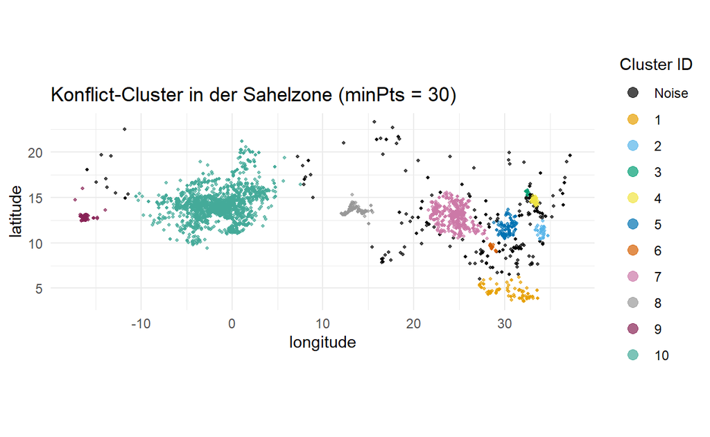

```r
# Bild zur Darstellung der Cluster mit ggplot2

# Einfaches Diagramm zur ausschließlichen Darstellung der Clusterpunkte

# Okabe-Ito Palette definieren

okabe_ito <- c(
  "#000000",  # 0 = Noise (schwarz)
  "#E69F00",
  "#56B4E9",
  "#009E73",
  "#F0E442",
  "#0072B2",
  "#D55E00",
  "#CC79A7",
  "#999999",
  "#882255",
  "#44AA99"
)

# Plot erstellen

p_clusters <- ggplot(
  GED_sahel_laea,
  aes(
    x = longitude,
    y = latitude,
    color = factor(cluster_id)
  )
) +

  # Legendenpunkte vergrößern
  guides(
  color = guide_legend(
    override.aes = list(size = 3)
    )
  ) +

  # Clusterpunkte
  geom_point(size = 0.8, alpha = 0.7) +
  coord_equal() +
  scale_color_manual(
    values = okabe_ito,
    labels = c("Noise", 1:10)
    ) +
  labs(
    color = "Cluster ID",
    title = paste0("Konflict-Cluster in der Sahelzone (minPts = ", minPts_value, ")")
  ) +
  theme_minimal()

# Plot anzeigen

p_clusters
```

**Aufklappen**

```r
# Speichern

 # ggsave(
 #   filename = paste0("plots/clusters_map_okabeito_minPts_", minPts_value, ".png"),
 #   plot = p_clusters,
 #   width = 10,
 #   height = 6,
 #   dpi = 300
 # )
```

# Cluster mit Ländern der Sahelzone

**Aufklappen**

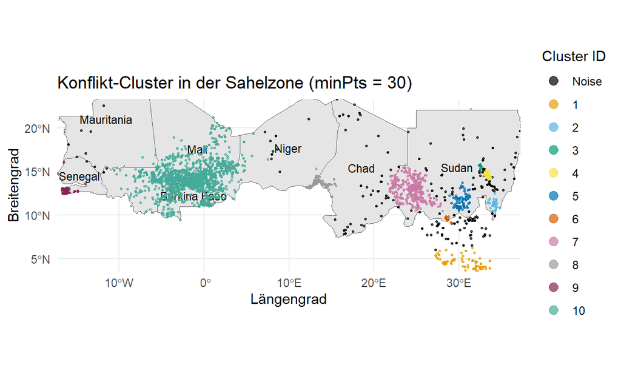

```r
# Cluster mit Ländern der Sahelzone

# Zusätzliche Abbildung: Karte (Sahelzone) + HDBSCAN-Cluster in Longitude/Latitude

# 1) Weltkarte als sf-Objekt laden

# sf steht für "simple features" und ist ein Datenstandard für Vektor-Geodaten

world_sf <- rnaturalearth::ne_countries(
  scale = "medium",
  returnclass = "sf"
)

# 2) Nur Sahel-Länder auswählen

sahel_map_sf <- world_sf |>
  filter(name %in% sahel_countries)

# 3) Farben der Okabe-Ito-Palette definieren
# 0 = Noise (schwarz)

okabe_ito_clusters <- c(
  "0"  = "#000000",  # Noise
  "1"  = "#E69F00",
  "2"  = "#56B4E9",
  "3"  = "#009E73",
  "4"  = "#F0E442",
  "5"  = "#0072B2",
  "6"  = "#D55E00",
  "7"  = "#CC79A7",
  "8"  = "#999999",
  "9"  = "#882255",
  "10" = "#44AA99"
)

# 4) Plot erstellen

p_clusters_map <- ggplot() +

  # Hintergrund: Länderflächen
  geom_sf(
    data = sahel_map_sf,
    fill = "grey90",
    color = "grey40",
    linewidth = 0.3
  ) +

  # Ländernamen
  geom_sf_text(
    data = sahel_map_sf,
    aes(label = name),
    size = 3,
    color = "black"
  ) +

  # Clusterpunkte
  geom_point(
    data = GED_sahel_laea,
    aes(
      x = longitude,
      y = latitude,
      color = factor(cluster_id)
    ),
    size = 0.6,
    alpha = 0.7
  ) +

  # Manuelle Farbskala
  scale_color_manual(
    values = okabe_ito_clusters,
    labels = c("Noise", 1:10)
  ) +

  # Legendenpunkte vergrößern
  guides(
  color = guide_legend(
    override.aes = list(size = 3)
    )
  ) +

  # Kartenausschnitt
  coord_sf(
    xlim = range(GED_sahel_laea$longitude),
    ylim = range(GED_sahel_laea$latitude),
    expand = FALSE
  ) +

  # Beschriftung
  labs(
    color = "Cluster ID",
    title = paste0("Konflikt-Cluster in der Sahelzone (minPts = ", minPts_value, ")"),
    x = "Längengrad",
    y = "Breitengrad"
  ) +

  theme_minimal()

# Plot anzeigen

p_clusters_map
```

**Aufklappen**

```r
# Speichern

 # ggsave(
 #   filename = paste0("plots/clusters_map_okabeito_sahel.png"),
 #   plot = p_clusters_map,
 #   width = 10,
 #   height = 6,
 #   dpi = 300
 # )

# Bedeutung der Warnung
# Die Berechnung des Beschriftungspunktes kann bei Grad-Koordinaten ungenau sein, weil sie eigentlich für projizierte Koordinaten gedacht ist
# --> Unkritisch, da nur der Ort des Labels betroffen ist
```

# Cluster mit vollständiger Karte von Afrika

**Aufklappen**

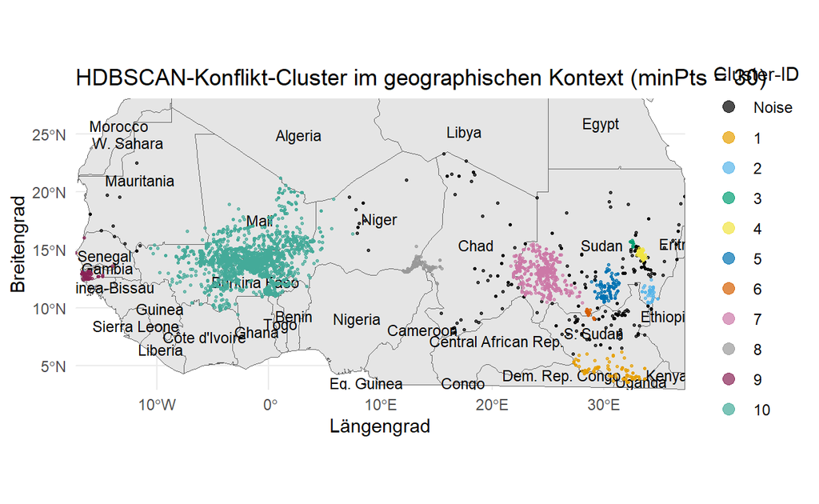

```r
GED_sahel_sf <- GED_sahel_sf |>
  mutate(cluster_id = GED_sahel_laea$cluster_id)

# Cluster mit vollständiger Afrika-Karte

# Komplette Abbildung: Cluster + Afrika-Karte + Ländernamen

# 1) Alle afrikanischen Länder laden

africa_sf <- rnaturalearth::ne_countries(
  scale = "medium",
  continent = "Africa",
  returnclass = "sf"
)

# 2) Bounding Box der Ereignisdaten erzeugen
# Grundlage: GED_sahel_sf liegt in WGS84 (Grad)

bbox_sahel <- st_bbox(GED_sahel_sf)

# 3) Kartenausschnitt manuell anpassen --> Nordgrenze bis 28°N, Südgrenze ab 3°N

bbox_africa_map <- bbox_sahel
bbox_africa_map["ymin"] <- 3
bbox_africa_map["ymax"] <- 28

# 4) Afrika-Karte auf diesen Bereich zuschneiden

africa_crop <- st_crop(africa_sf, bbox_africa_map)

# 5) Okabe-Ito-Farbpalette definieren
# 0 = Noise

okabe_ito_clusters <- c(
  "0"  = "#000000",  # Noise
  "1"  = "#E69F00",
  "2"  = "#56B4E9",
  "3"  = "#009E73",
  "4"  = "#F0E442",
  "5"  = "#0072B2",
  "6"  = "#D55E00",
  "7"  = "#CC79A7",
  "8"  = "#999999",
  "9"  = "#882255",
  "10" = "#44AA99"
)

# 6) Plot erstellen

p_clusters_africa <- ggplot() +

  # Hintergrund: Länderflächen
  geom_sf(
    data = africa_crop,
    fill = "grey90",
    color = "grey40",
    linewidth = 0.3
  ) +

  # Ländernamen
  geom_sf_text(
    data = africa_crop,
    aes(label = name),
    size = 3,
    color = "black"
  ) +

  # Clusterpunkte
  geom_sf(
    data = GED_sahel_sf,
    aes(color = factor(cluster_id)),
    size = 0.6,
    alpha = 0.7
  ) +

  # Farbskala
  scale_color_manual(
    values = okabe_ito_clusters,
    breaks = as.character(0:10),
    labels = c("Noise", as.character(1:10))
  ) +


  # Legendenpunkte vergrößern
  guides(
  color = guide_legend(
    override.aes = list(size = 3)
    )
  ) +

  # Kartenausschnitt
  coord_sf(
    xlim = c(bbox_africa_map["xmin"], bbox_africa_map["xmax"]),
    ylim = c(bbox_africa_map["ymin"], bbox_africa_map["ymax"]),
    expand = FALSE
  ) +

  # Beschriftung
  labs(
    color = "Cluster-ID",
    title = paste0("HDBSCAN-Konflikt-Cluster im geographischen Kontext (minPts = ", minPts_value, ")"),
    x = "Längengrad",
    y = "Breitengrad"
  ) +

  theme_minimal()

# Plot anzeigen

p_clusters_africa
```

**Aufklappen**

```r
# Speichern
 #
 # ggsave(
 #   filename = paste0("plots/clusters_map_okabeito_africa_complete.png"),
 #   plot = p_clusters_africa,
 #   width = 10,
 #   height = 6,
 #   dpi = 300
 # )
```

# Deskriptive Daten zu den Clustern

**Aufklappen**

```r
# Vorbereitung der Daten für die Clusterbeschreibung
# Es werden nur echte Cluster betrachtet, Noise (cluster_id = 0) wird ausgeschlossen

GED_sahel_clustered <- GED_sahel_laea |>
  filter(cluster_id != 0)
```

**Anzahl Konflikte pro Cluster mit Anzahl an Events**

**Aufklappen**

```r
# Anzahl Konflikte pro Cluster mit Anzahl an Events (cluster_size) --> Clustergröße

GED_sahel_laea |>
  filter(cluster_id != 0) |>
  group_by(cluster_id) |>
  summarise(
    n_conflicts = n_distinct(conflict_new_id),
    cluster_size = n()
  ) |>
  arrange(desc(n_conflicts))
```

```
Simple feature collection with 10 features and 3 fields
Geometry type: MULTIPOINT
Dimension:     XY
Bounding box:  xmin: -2904076 ymin: -1160338 xmax: 2688770 ymax: 705411.9
Projected CRS: +proj=laea +lat_0=15 +lon_0=10 +datum=WGS84 +units=m +no_defs
# A tibble: 10 × 4
   cluster_id n_conflicts cluster_size                        geometry
        <dbl>       <int>        <int>                <MULTIPOINT [m]>
 1         10          46         3378 ((-2197585 115934.4), (-217316…
 2          7          39         1356 ((1256369 -120877.7), (1282010…
 3          8          10          266 ((219788.1 -196579.6), (231999…
 4          1           9          130 ((1910495 -999748.9), (1914781…
 5          5           8          233 ((1990186 -284923), (2040653 -…
 6          6           7           38 ((2012047 -508220.6), (2014772…
 7          2           4           54 ((2532773 -269253.6), (2541069…
 8          9           4           82 ((-2904076 148793.9), (-287110…
 9          3           3          340 ((2372951 197251.2), (2387313 …
10          4           3           87 ((2449215 137207.3), (2450811 …
```

**Dominanter Konflikt pro Cluster**

**Aufklappen**

```r
# Dominanter Konflikt pro Cluster (share/purity-like measure) --> Anteil des häufigsten Konflikts vom Gesamtanteil

dominance_by_cluster <- GED_sahel_clustered |>
  count(cluster_id, conflict_new_id, conflict_name, name = "n") |>
  group_by(cluster_id) |>
  mutate(
    cluster_size = sum(n),
    share = n / cluster_size
  ) |>
  arrange(cluster_id, desc(share)) |>
  slice(1) |>
  ungroup() |>
  select(cluster_id, conflict_new_id, conflict_name, cluster_size, n_dominant = n, dominant_share = share)

dominance_by_cluster
```

```
Simple feature collection with 10 features and 6 fields
Geometry type: MULTIPOINT
Dimension:     XY
Bounding box:  xmin: -2871102 ymin: -1160338 xmax: 2688770 ymax: 705411.9
Projected CRS: +proj=laea +lat_0=15 +lon_0=10 +datum=WGS84 +units=m +no_defs
# A tibble: 10 × 7
   cluster_id conflict_new_id conflict_name    cluster_size n_dominant
        <dbl>           <int> <chr>                   <int>      <int>
 1          1             559 LRA - Civilians           130         80
 2          2             309 Sudan: Governme…           54         45
 3          3             309 Sudan: Governme…          340        216
 4          4           15913 RSF - Civilians            87         59
 5          5             309 Sudan: Governme…          233        141
 6          6            4974 Misseriya - Ngo…           38         20
 7          7             309 Sudan: Governme…         1356        625
 8          8           13639 Niger: Islamic …          266         90
 9          9             375 Senegal: Casama…           82         58
10         10           11347 Mali: Government         3378        791
# ℹ 2 more variables: dominant_share <dbl>, geometry <MULTIPOINT [m]>
```

**Fünf Top-Konflikte pro Cluster**

**Aufklappen**

```r
# Die fünf Top-Konflikte pro Cluster

top_conflicts_by_cluster <- GED_sahel_clustered |>
  count(cluster_id, conflict_new_id, conflict_name, name = "n") |>
  group_by(cluster_id) |>
  mutate(share = n / sum(n)) |>
  arrange(cluster_id, desc(share)) |>
  slice_head(n = 5) |>
  ungroup()

top_conflicts_by_cluster
```

```
Simple feature collection with 44 features and 5 fields
Geometry type: GEOMETRY
Dimension:     XY
Bounding box:  xmin: -2904076 ymin: -1160338 xmax: 2688770 ymax: 705411.9
Projected CRS: +proj=laea +lat_0=15 +lon_0=10 +datum=WGS84 +units=m +no_defs
# A tibble: 44 × 6
   cluster_id conflict_new_id conflict_name                       n
        <dbl>           <int> <chr>                           <int>
 1          1             559 LRA - Civilians                    80
 2          1             314 Uganda: Government                 26
 3          1             309 Sudan: Government                  16
 4          1             554 SPLM/A - Civilians                  2
 5          1            4662 LRA - SPLM/A                        2
 6          2             309 Sudan: Government                  45
 7          2             480 Government of Sudan - Civilians     6
 8          2           15324 Hausa - Funj                        2
 9          2           15913 RSF - Civilians                     1
10          3             309 Sudan: Government                 216
# ℹ 34 more rows
# ℹ 2 more variables: geometry <GEOMETRY [m]>, share <dbl>
```

# Anzahl Konflikte pro Cluster

**Aufklappen**

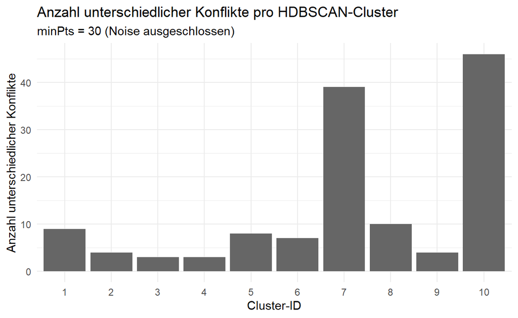

```r
# Plot 1: Anzahl unterschiedlicher Konflikte pro Cluster (Balkendiagramm)

conflicts_per_cluster <- GED_sahel_laea |>
  filter(cluster_id != 0) |>
  group_by(cluster_id) |>
  summarise(
    n_conflicts = n_distinct(conflict_new_id),
    cluster_size = n(),
    .groups = "drop"
  ) |>
  arrange(cluster_id)

p_conflicts <- ggplot(
  conflicts_per_cluster,
  aes(x = factor(cluster_id), y = n_conflicts)
) +
  geom_col(fill = "grey40") +
  labs(
    title = "Anzahl unterschiedlicher Konflikte pro HDBSCAN-Cluster",
    subtitle = paste0("minPts = ", minPts_value, " (Noise ausgeschlossen)"),
    x = "Cluster-ID",
    y = "Anzahl unterschiedlicher Konflikte"
  ) +
  theme_minimal()

p_conflicts
```

**Aufklappen**

```r
# ggsave(
#   filename = paste0("plots/new_bar_conflicts_per_cluster_minPts_", minPts_value, ".png"),
#   plot = p_conflicts,
#   width = 10,
#   height = 6,
#   dpi = 300
# )
```

# Dominant Share pro Cluster

**Aufklappen**

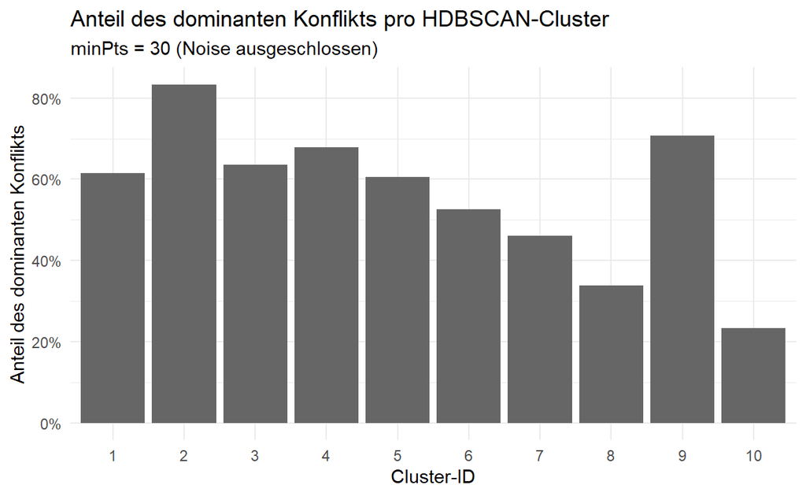

```r
# Plot 2: Anteil des dominanten Konflikts pro Cluster (Homogenität)

p_dominance <- ggplot(
  dominance_by_cluster,
  aes(x = factor(cluster_id), y = dominant_share)
) +
  geom_col(fill = "grey40") +
  scale_y_continuous(labels = scales::percent) +
  labs(
    title = "Anteil des dominanten Konflikts pro HDBSCAN-Cluster",
    subtitle = paste0("minPts = ", minPts_value, " (Noise ausgeschlossen)"),
    x = "Cluster-ID",
    y = "Anteil des dominanten Konflikts"
  ) +
  theme_minimal()

p_dominance
```

**Aufklappen**

```r
# ggsave(
#   filename = paste0("plots/new_bar_dominant_share_per_cluster_minPts_", minPts_value, ".png"),
#   plot = p_dominance,
#   width = 10,
#   height = 6,
#   dpi = 300
# )
```